# Анализ рынка недвижимости. Исследование объявлений о продаже квартир в Санкт-Петербурге.

**Изучение факторов, влияющих на цену квартир в центре города**

Для изучения влияния на цену площади, числа комнат, удаленности от центра построим матрицу диаграмм рассеивания.

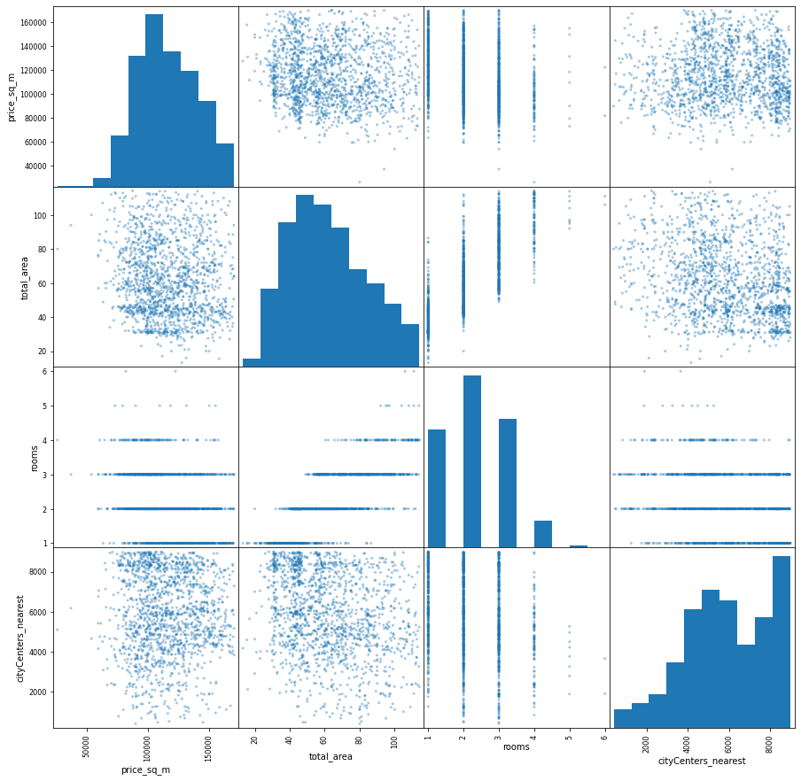

```python
pd.plotting.scatter_matrix(data_city_center[['price_sq_m', 'total_area', 'rooms', 'cityCenters_nearest']] , alpha=0.4, figsize=(15, 15),);
```

Цена квадратного метра однокомнатных квартир начинается с более высоких значений, чем двух и трех комнатных. Видно, что самую низкую цену за квадратный метр можно найти среди трехкомнатных квартир. Интересно еще, что цена четырехкомнатных квартир начинается с чють более высоких значений, чем у трехкомнатных.

Что касается площади квартир, на графике видно, что цены за квадратный метр на квартиры с площадью менее 40 кв м сосредоточены в более высоких значениях. С увеличением площади увеличивается и размах цен. Также видны скопления точек графика на значениях площадей около 30 кв м, 45 кв м и 60 кв м. Квартир с таким площадями в центре больше остальных.

Еще интересно, что ближе к самому центру преобладают 2-х, 3-х комнатные квартиры и практически нет однокомнатных.

Посчитаем коэффициенты корреляций.

```python
data_city_center[['price_sq_m', 'cityCenters_nearest', 'rooms', 'total_area']].corr().sort_values(by='price_sq_m', ascending=False)
```

|  | price_sq_m | cityCenters_nearest | rooms | total_area |
| --- | --- | --- | --- | --- |
| price_sq_m | 1.000000 | -0.020232 | -0.299953 | -0.101393 |
| cityCenters_nearest | -0.020232 | 1.000000 | -0.240003 | -0.259706 |
| total_area | -0.101393 | -0.259706 | 0.787981 | 1.000000 |
| rooms | -0.299953 | -0.240003 | 1.000000 | 0.787981 |

Коэффициенты корреляции поддтверждают выводы по графику.

В центре города, в отличии от всей области удаленность от центра уже фактически не влияет на цену (самый низкий коэффициент). Наибольшее влияние здесь оказывает количество комнат - чем больше комнат, тем ниже цена за квадратный метр. Коэффициент корреляции цены с общей площадью также отрицательный и здесь площадь, в отличие от общих данных, оказывает на цену меньшее влияние, чем число комнат.

**Зависимость цены квартиры в центре от этажа**

Для выявления зависимости построим диаграммы размаха цен для первого, последнего и других этажей.

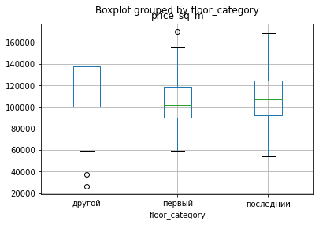

```python
data_city_center.boxplot(column='price_sq_m', by='floor_category');
```

Здесь прослеживается та же зависимость, что и в общих данных. Самые низкие цены на квартиры, расположенные на первых этажах. Самые высокие на квартиры не на первом и не на последнем этажах.

Посмотрим статистику. Построим сводную таблицу с медианой по этажам

```python
price_сс_floor_category = data_city_center.pivot_table(index = 'floor_category',
                                            values = 'price_sq_m', aggfunc = ['median', 'count'])
price_сс_floor_category.columns = ['median_price', 'count']
price_сс_floor_category['%_category'] = price_сс_floor_category['count'] / price_сс_floor_category['count'].sum() * 100
price_сс_floor_category.sort_values(by='median_price')
```

| floor_category | median_price | count | %_category |
| --- | --- | --- | --- |
| первый | 102103.999495 | 202 | 12.6250 |
| последний | 106916.221034 | 241 | 15.0625 |
| другой | 117699.115044 | 1157 | 72.3125 |

Как и в общих данных большая часть продаваемых квартир (72%) не на первом и последнем этажах. Доля последних этажей в центре немного выше, чем в общем в области 15% (в общих данных 13%). Разница медианы цен на первом и другом этажах в центре 13% (в общих данных эти медианы отличались на 17%), между первым этажом и общей медианой по центру - 10% (в общих данных эта разница 14%).Также медиана цены последнего этажа в центре меньше медианы в целом по центру на 6%, а медианы других этажей на 10%.

Можно сделать вывод, что цена квадратного метра в центре зависит от этажа, на которм находится квартира, но в меньшей степени , чем в квартирах из общей выборки.

**Зависимость цены на квартиры в центре от даты размещения**

Построим диаграммы размаха для цены объявлений по дням недели.

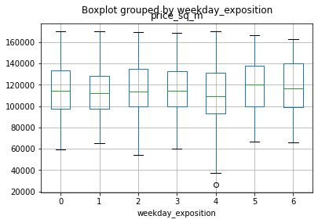

```python
data_city_center.boxplot(column='price_sq_m', by='weekday_exposition');
```

В отличии от общих данных, здесь прослеживается зависимость. Квартиры с более низкой ценой за квадратный метр попадают в продажу по пятницам, а с более высокой по суббатам. Также, для объявлений, размещенных в пятницу характерен самый высокий размах цен.В то же время, не смотря на то, что самые высокие медианы цен по субботам и воскресеньям, верхняя граница размаха в эти дни самая низкая. Возможно это связано с меньшим количеством объявлений, размещаемых в выходные.

Посмотрим статистику в сводной таблице.

```python
price_сс_weekday_exposition = data_city_center.pivot_table(index = 'weekday_exposition',
                                            values = 'price_sq_m', aggfunc = ['median', 'count'])
price_сс_weekday_exposition.columns = ['median_price', 'count']
price_сс_weekday_exposition['%_weekday'] = price_сс_weekday_exposition['count'] / price_сс_weekday_exposition['count'].sum() * 100
price_сс_weekday_exposition.sort_values(by='median_price')
```

| weekday_exposition | median_price | count | %_weekday |
| --- | --- | --- | --- |
| 4 | 109275.120504 | 294 | 18.3750 |
| 1 | 112145.948072 | 270 | 16.8750 |
| 2 | 113386.603790 | 256 | 16.0000 |
| 0 | 114259.651229 | 232 | 14.5000 |
| 3 | 114357.423703 | 314 | 19.6250 |
| 6 | 116666.666667 | 103 | 6.4375 |
| 5 | 120576.671035 | 131 | 8.1875 |

Построим диаграммы размаха для цены объявлений по месяцам

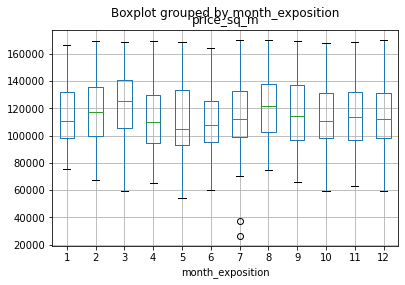

```python
data_city_center.boxplot(column='price_sq_m', by='month_exposition');
```

Различия в цене в зависимости от месяца в центре прослеживаются более явно, чем по всей области. Самые высокие цены на недвижимость в центре в марте и в августе, тогда как по всем данным самые высокие цены приходятся на август, сентябрь и октябрь. Самые низкие в мае и в июне. По всей выборке самые низкие цены в июне и декабре. В центре более явно прослеживается сезонность в продажах квартир.

Посмотрим статистику по месяцам.

```python
price_сс_month_exposition = data_city_center.pivot_table(index = 'month_exposition',
                                            values = 'price_sq_m', aggfunc = ['median', 'count'])
price_сс_month_exposition.columns = ['median_price', 'count']
price_сс_month_exposition['%_month'] = price_сс_month_exposition['count'] / price_сс_month_exposition['count'].sum() * 100
price_сс_month_exposition.sort_values(by='median_price')
```

| month_exposition | median_price | count | %_month |
| --- | --- | --- | --- |
| 5 | 104838.709677 | 97 | 6.0625 |
| 6 | 107716.049383 | 135 | 8.4375 |
| 4 | 109929.078014 | 131 | 8.1875 |
| 10 | 110816.326531 | 155 | 9.6875 |
| 1 | 110991.379310 | 87 | 5.4375 |
| 12 | 112356.431714 | 116 | 7.2500 |
| 7 | 112461.197339 | 124 | 7.7500 |
| 11 | 113364.011149 | 170 | 10.6250 |
| 9 | 114253.393665 | 155 | 9.6875 |
| 2 | 117052.682522 | 142 | 8.8750 |
| 8 | 121540.273556 | 136 | 8.5000 |
| 3 | 125416.115735 | 152 | 9.5000 |

Самые низкие цены на квартиры в центре были в май и июне. В целом по выборке на эти месяцы также приходится самый низкий уровень цен, только самая низкая медиана цены в общих данных в мае, а июнь на втором месте. Наибольшие отличия наблюдаются в месяцах с самым высоким уровнем цен. Для центра самым дорогим месяцем оказался март. В общих данных самая высокая медиана цены в августе, а март на 4-м месте.

Также есть отличия в количестве размещаемых объявлений. В общем по продаже квартир больше всего объявлений (11,2%) разместили в феврале. Максимальное количество объявлений о продаже квартир в центре появилось в ноябре (10,6%), на февраль прищлось всего 8,9% таких объявлений.

Построим диаграммы размаха для цены объявлений по годам

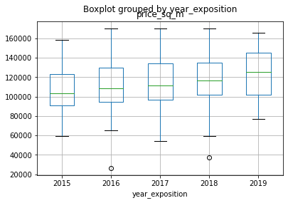

```python
data_city_center.boxplot(column='price_sq_m', by='year_exposition');
```

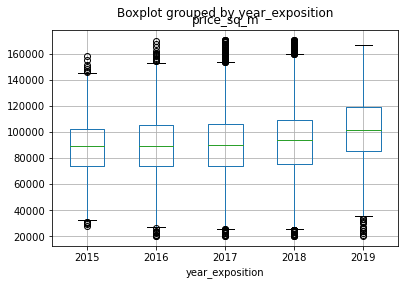

```python
data_new.boxplot(column='price_sq_m', by='year_exposition');
```

На первый взгляд, кажется, что изменеие медианы цены по центру города в зависимости от года, в целом соответствует изменеиям этого показателя в общих данных. Наблюдается рост цен, самый большой скачок в 2019 г. по сравнению с 2018 г. Проверим статистику.

```python
price_сс_year_exposition = data_city_center.pivot_table(index = 'year_exposition',
                                            values = 'price_sq_m', aggfunc = ['median', 'count'])
price_сс_year_exposition.columns = ['median_price', 'count']
price_сс_year_exposition['%_year'] = price_сс_year_exposition['count'] / price_сс_year_exposition['count'].sum() * 100
price_сс_year_exposition.sort_values(by='median_price')
```

| year_exposition | median_price | count | %_year |
| --- | --- | --- | --- |
| 2015 | 102998.062335 | 50 | 3.1250 |
| 2016 | 108333.333333 | 201 | 12.5625 |
| 2017 | 111731.843575 | 721 | 45.0625 |
| 2018 | 116707.317073 | 551 | 34.4375 |
| 2019 | 125000.000000 | 77 | 4.8125 |

Действительно в 2019 г. медиана цены по центру выросла на 7,1% по сравнению с 2018, но рост цен в общем по области был выше - медиана 2019 больше 2018 на 8,6%. В 2018 рост медианной цены в центре по сравнению с 2017 составил 4,4%. По общим данным 4,2% -незначительно меньше.

Можно сказать, что с годами цены на квартиры в центре растут, но немного меньше чем в целом по области.

Еще можно отметить, что в то время как общее число объявлений в 2017 и 2018 годах примерно одинаковой, объявлений о продаже квартир в центре в 2018 году на 23,6% меньше, чем в 2017 г.

## Общий вывод

В исследовании необходимо было установить параметры для определения рыночной цены недвижимости.

В ходе исследования было выявлены следующие значения характерные в целом для квартир, продающихся в области:

- большая часть квартир соответствует площади 30-60 кв м
- больше всего продается однокомнатных квартир, на втором месте двухкомнатные и затем трехкомнатные.
- самаые распространенные цены продажи 3-5 млн (больше всего продается квартир с ценой около 3,7 млн р)
- Большинство квартир продется в диапазоне цен за квадратный метр 80-105 тыс руб., среди них самая распростарненная 90-100тыс.р. за квадратный метр Большая часть кваартир продается за 95 дней(примерно 75% всех объявлений сняты с продажи в этот период). В течеии первых 30 дней продалось 15% квартир из выборки.

Для квартир в центре города характерны несколько другие параметры:

- в основном в центре, также как и в целом по области продаются квартиры площадью 30-60 кв м, но доля квартир с большей площадью здесь несколько выше. например квартир площадью около 70 кв м продается почти столько же, сколько и 30.
- если смотреть по количеству комнат в центре больше всего продается двухкомнатных квартир, на втором месте трехкомнатнные, а однокомнатные квартиры, в отличии от всей выборки находятся на третьем месте по количеству объявлений.
- цена за квадратный метр в центре выше, чем в целом по области. Больше всего квартир в диапазоне от 90 до 140 тыс руб. за квадратный метр. Самая распространенная цена здесь 100-110 тыс руб. за кв м. (на 18% выше чем в целом по области). Квартиры в центре продаются дольше, чем в целом по выборке. Однако доля квартир проданных в первые дни размещения здесь выше (15% квартир продаются за 20 дней)

При исследовании факторов, влияющих на цену квартир были выявлены следующие особенности:

Для квартир в целом по области:

- Больше всего цена таких квартир зависит от удаленности от центра (самая высокая корреляция среди исследуемых факторов). С увеличением расстояния от центра цена квадратного метра снижается;
- На втором месте по влиянию размер общей площади квартиры (чем больше площадь, тем ниже цена за квадратный метр);
- Количество комнат же практически не оказывает влияния на изменение цены (самый низкий коэффицент корреляции).

Влияние этих же факторов на цену квадратного метра недвижимости в центре распределенно по другому:

- Наибольшее влияние на цену квадратного метра оказывает количество комнат (самый высокий коэффициент корреляции)- чем меньше комнат, тем выше цена за квадратный метр.
- На втором месте по влиянию на цену общая площадь - также с увеличением площади цена квадратного метра снижается но не столь значительно.
- Удаленность же от центра в данном случае на цену практически не влияет (самый низкий коэффициент корреляции).

Цена квадратного метра также зависит от этажа на котором расположена квартира. Как целом по выборке так и в центре города самые низкие цены на квартиры на первых этажах, затем по уровню цен идут квартиры, находящиеся на последних этажах, уровень цен квартир на других этажах выше. Однако по центру города разница цены квадратного метра в зависимости от этажа несколько меньше.

Изучение влияния времени размещения объявления на цену квадратного метра показало следующие особенности для всей выборки:

- В целом по области цена в зависимости от дня недели размещения объявления не меняется (отклонение между самой большой и самой маленькой медианой 1%).
- Цена квадратного метра меняется в зависимости от месяца размещения объявления. Самые низкие цены на квартиры характеры для объявлений в июне, самые высокие - в августе. Разница между максимальной и минимальной медианной ценой 5%.
- Наибольшее изменение цен прослеживается в зависимосте от года размещения. очевиден общий рост цен в течении изучаемого периода. Максимальный рост произошел в 2019 г. (медианная цена выросла на 8,6%).

Для квартир в центре прослеживаются другие особенность в зависимости от времени размещения:

- Более очевидно влияние на цену дня недели размещения. Самые низкие цены в объявлениях, размещенных в пятницу, самые высокие - в субботу. Разница между максимальной и минимальной медианной ценой по дням в центре составляет уже 9%.
- Также для центра характерна зависимость цены от месяца размещения объявления. Но месяцы с самой низкой и самой высокой ценой отличаются от общих данных по таблице. Самый высокий уровень цен в центре характерен для квартир продающихся в марте (в общих данных медианная цена в этом месяце на 4-м месте). Самый низкий уровень цен в мае (июнь на 2-м месте).
- Рост цен с годами прослеживается и в центре города, но несколько меньше меньше, чем в целом по области (медиана цены в 2019 г выше че в 2018 на 7,1%).

Среди 10 крупнейших населенных пунктов самая низкая цена квадратного метра характерна для Выборга. Самая высокая очевидно для Санкт-Петербурга, на втором месте по уровню цен находится Пушкин. В целом разница между самой высокой и самой низкой средней ценой по крупным регионам составляет 81%.